# py27_Math_Statistics_NumPy_2_统计函数

## 二、统计函数

### 1 统计函数

**求和、平均值、中值、方差**

> - np.sum() 求和。参数：out 、axis 、dtype
> - np.mean() 平均值。参数：out 、axis 、dtype
> - np.average() 平均值。可指定权值，但没有out 和 dtype 等参数
> - np.median() 中值。参数：out 、axis 、dtype。长度为偶数时，得到正中间两个数的均值。
> - np.std() 标准差。参数：out 、axis 、dtype
> - np.var() 方差。参数：out 、axis 、dtype

```python
import numpy as np
```

```python
a = np.random.randint(0,10,size = (4,5))
print a
print np.sum(a) # 全部值求和
print np.sum(a,axis = 1) # 沿着轴求和
print np.sum(a,axis = 0)
```

```
[[7 0 5 9 1]
 [3 3 3 7 5]
 [2 8 2 8 9]
 [7 1 1 6 3]]
90
[22 21 29 18]
[19 12 11 30 18]
```

```python
b = np.ones(1000000,dtype = np.float32) * 1.1 # 一个很大的单精度浮点数组
print b # 1.1 无法使用浮点数精确表示，存在一些误差
print np.sum(b) # 使用单精度累加变量进行累加计算，误差会越来越大
print np.sum(b, dtype = np.double) # 使用双精度浮点数则计算结果正确
```

```
[ 1.10000002  1.10000002  1.10000002 ...,  1.10000002  1.10000002
  1.10000002]
1.1e+06
1100000.02384
```

```python
print np.mean(a,axis = 1) # 整数数组 使用双精度浮点数计算（默认）
print np.mean(b) # 单精度浮点数 使用单精度浮点数计算（默认）
print np.mean(b,dtype = np.double) # 使用双精度浮点数计算
```

```
[ 4.4  4.2  5.8  3.6]
1.1
1.10000002384
```

**其他统计函数**

> - unique() 返回数组中所有不同的值，并按由小到大排序。参数：return_index、return_inverse
> - bincount() 对整数数组中各个元素出现的次数进行统计，所有元素为非负。参数：weights
> - histogram() 对一维数组进行直方图统计

```python
a = np.random.randint(0,5,10)
print a
```

```
[3 3 1 0 0 3 2 4 0 3]
```

```python
print np.unique(a) # 数组a中所有整数，并排序
x,idx = np.unique(a,return_index=True) # 返回两个数组，第二个数组为第一个数组在原始数组中的下标
print x
print idx
print a[idx] # idx中是数组x中每个元素在数组a中的下标
print '--------------------------------'
y,idy = np.unique(a,return_inverse=True)
print y
print idy # idy 是原始数组a 中每个元素在数组x中的下标
print all(x[idy] == a)  # a 和 x[idy] 完全相同
```

```
[0 1 2 3 4]
[0 1 2 3 4]
[3 2 6 0 7]
[0 1 2 3 4]
--------------------------------
[0 1 2 3 4]
[3 3 1 0 0 3 2 4 0 3]
True
```

```python
print np.bincount(a) # 数组a中 0出现3次，1出现1次，2出现1次……
print '--------------------------------'
x = np.array([0,1,2,2,1,1,0])
w = np.array([0.1,0.2,0.3,0.4,0.5,0.8,1.2])
print x
print np.unique(x)
print np.bincount(x,w) # bincount(x,weights=w) 1.3是数组x中0所对应的w中的（0.1 和1.2） 的和……
print '--------------------------------'
print np.bincount(x)
print np.bincount(x,w)/np.bincount(x) # 求平均，求和结果与次数相除
```

```
[3 1 1 4 1]
--------------------------------
[0 1 2 2 1 1 0]
[0 1 2]
[ 1.3  1.5  0.7]
--------------------------------
[2 3 2]
[ 0.65  0.5   0.35]
```

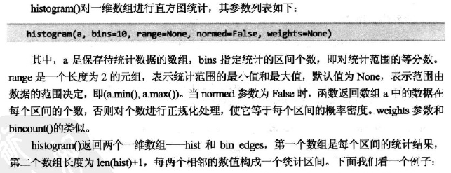

```python
from IPython.display import Image
Image(filename="picture\histogram.png")
```

```python
a = np.random.rand(100)
print np.histogram(a,bins=5,range=(0,1))
print np.histogram(a,bins=[0,0.4,0.8,1.0],range=(0,1))
```

```
(array([15, 21, 18, 23, 23]), array([ 0. ,  0.2,  0.4,  0.6,  0.8,  1. ]))
(array([36, 41, 23]), array([ 0. ,  0.4,  0.8,  1. ]))
```

### 2 最值和排序

> - np.min() 最小值。参数：axis、out
> - np.max() 最大值。参数：axis、out
> - np.ptp() 极值。参数：axis、out
> - np.argmax() 最大值下标。参数：axis、out
> - np.argmin() 最小值下标。参数：axis、out
> - np.unravel_index() 一维下标变多维下标
> - np.sort()
> - np.argsort() 下标排序

```python
a = np.random.randint(0,10,size = (4,5))
print a
print np.argmax(a) # 数组a 中最大值的下标，有多个最值时返回第一个值的下标
idx = np.argmax(a,axis = 1) # 每行中最大值位置
print idx
b = a[xrange(a.shape[0]),idx] # 取出每行的最大值
print b

print a.ravel()
print a.ravel()[2] # 求平坦化之后数组中的第二个元素
```

```
[[4 7 2 7 9]
 [4 8 8 8 7]
 [2 0 0 6 1]
 [5 5 7 5 6]]
4
[4 1 3 2]
[9 8 6 7]
[4 7 2 7 9 4 8 8 8 7 2 0 0 6 1 5 5 7 5 6]
2
```

```python
idx = np.unravel_index(2,a.shape) # 第一个参数为一维下标值，第二个参数为多维数组的形状
print idx
print a[idx]
```

[output not shown]

```python
print np.sort(a) # 对每行进行排序，默认axis = -1，即按最后一轴进行排序
print np.sort(a, axis = 0) # 对每列进行排序
```

[output not shown]

```python
idx = np.argsort(a) # 返回数组的排序下标
print idx
```

[output not shown]

- 使用以下方式可以对两个相互关联的数组进行排序，即从数组a 产生排序下标数组，然后使用它对数组c 进行排序。
  > - kind：指定排序算法
  > - 结构数组中，使用order 指定排序所使用的字段

```python
x,_ = np.ogrid[:a.shape[0],:a.shape[1]] # 产生第0轴的下标
print x
b = a[x,idx] # 和 np.sort(a) 的结果相同
print b
```

[output not shown]

### 3 多项式函数

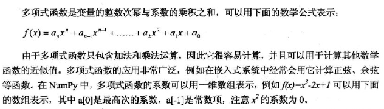

```python
from IPython.display import Image
Image(filename="picture\polynomial function.png")
```

```python
a = np.array([1,0,-2,1])
p = np.poly1d(a) # 用poly1d() 将系数转换为 poly1d（一元多项式）对象，像函数一样调用，返回多项式函数的值
print a
print type(p)
print p(np.linspace(0,1,5)) # 调用
```

```
[ 1  0 -2  1]
<class 'numpy.lib.polynomial.poly1d'>
[ 1.        0.515625  0.125    -0.078125  0.      ]
```

```python
# 对poly1d对象进行加减乘除相当于对相应的多项式函数进行计算
print p + [-2,1] # 和 p + np.poly1d([-2,1]) 相同
print '----------------------'
print p * p # 两个3次多项式相乘得到一个6次多项式
print '----------------------'
print p / [1,1] # 除法返回两个多项式，分别为商式和余式，这是因为多项式的除法不一定能正好整除
print '----------------------'
print p == np.poly1d([ 1., -1., -1.]) * [1,1,] + 2
```

```
   3
1 x - 4 x + 2
----------------------
   6     4     3     2
1 x - 4 x + 2 x + 4 x - 4 x + 1
----------------------
(poly1d([ 1., -1., -1.]), poly1d([ 2.]))
----------------------
True
```

```python
print dir(p)
```

[output not shown]

```python
print p.deriv() # 微分
print p.integ() # 积分
print p.integ().deriv() == p
```

```
   2
3 x - 2
      4     2
0.25 x - 1 x + 1 x
True
```

```python
r = np.roots(p) # 多项式的根
print r
print p(r) # 将根带入多项式计算，得到的值近似为0
print np.poly(r) # 将根转换回多项式的系数
```

```
[-1.61803399  1.          0.61803399]
[  2.33146835e-15   4.44089210e-16   1.11022302e-16]
[  1.00000000e+00  -7.77156117e-16  -2.00000000e+00   1.00000000e+00]
```

- 直接使用NumPy提供的多项式函数对表示多项式系数的数值进行运算

  > np.polyfit() 对一组数据使用多项式函数进行拟合，找到和这组数据最接近的多项式系数

```python
np.poly # 按Tab键补全
```

```python
x = np.linspace(-np.pi/2,np.pi/2,1000)   # 用多项式函数拟合正弦函数
y = np.sin(x)

for deg in [3,5,7]:
    a = np.polyfit(x,y,deg) # y 为目标函数的数值；deg 为多项式函数的最高阶数
    error = np.abs(np.polyval(a,x)-y)
    print 'poly %d :' % deg,a
    print 'max error of order %d' % deg,np.max(error)
```

```
poly 3 : [ -1.45021094e-01  -1.57297572e-16   9.88749145e-01   7.35378400e-18]
max error of order 3 0.00894699376707
poly 5 : [  7.57279944e-03  -5.91882051e-17  -1.65823793e-01   5.94974569e-17
   9.99770071e-01  -1.20517890e-17]
max error of order 5 0.000157408614172
poly 7 : [ -1.84445514e-04  -7.52650522e-17   8.30942467e-03   2.43671965e-16
  -1.66651593e-01  -2.04363743e-16   9.99997468e-01   9.05287177e-18]
max error of order 7 1.52682558063e-06
```

### 4 分段函数

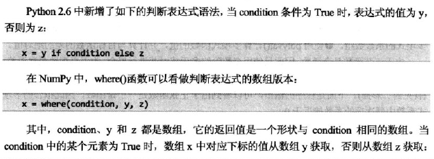

```python
from IPython.display import Image
Image(filename="picture\piecewise function.png")
```

```python
x = np.arange(10)
print x
print np.where(x<5,9-x,0) # 如果y 和 z 是单个数值，或者它们的形状与condition的不同，则先通过广播使其一致
print np.where(x>6,2*x,0)
```

[output not shown]

[output not shown]

- 计算分为三段的三角波形。
  - 通过frompyfunc()实现的代码，见“一（2）自定义 ufunc函数”

```python
def triangle_wave(x,c,c0,hc):
    x = x - x.astype(np.int) # 三角波的周期为1，因此只取x坐标的小数部分进行计算
    return np.where(x>=c,0,np.where(x<c0,x/c0*hc,(c-x)/(c-c0)*hc))
```

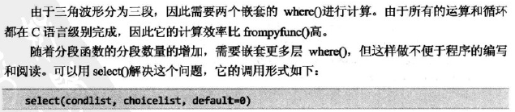

```python
from IPython.display import Image
Image(filename="picture\piecewise function 2.png")
```

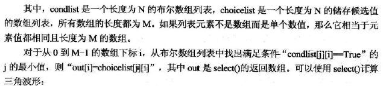

```python
Image(filename="picture\piecewise function 3.png")
```

```python
def triangle_wave(x,c,c0,hc):
    x = x - x.astype(np.int) # 三角波的周期为1，因此只取x坐标的小数部分进行计算
    return np.select([x>=c,x<c0,True],[0,x/c0*hc,(c-x)/(c-c0)*hc])
```

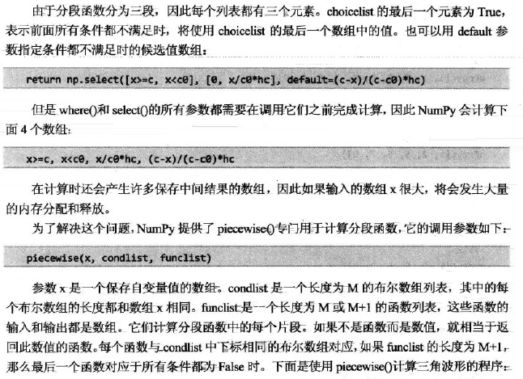

```python
Image(filename="picture\piecewise function 4.png")
```

```python
def triangle_wave(x,c,c0,hc):
    x = x - x.astype(np.int) # 三角波的周期为1，因此只取x坐标的小数部分进行计算
    return np.piecewise(x,
                       [x>=c,x<c0],
                       [o, # x>=c
                       lambda x: x/c0*hc, # x<c0
                       lambda x: (c-x)/(c-c0)*hc]) # else
```